# Vermont police stops

**September 8th, 2018**

# Sources

Data are taken from: https://openpolicing.stanford.edu/

On a typical day in the United States, police officers make more than 50,000 traffic stops. Their team is gathering, analyzing, and releasing records from millions of traffic stops by law enforcement agencies across the country. Their goal is to help researchers, journalists, and policymakers investigate and improve interactions between police and the public.

# Introduction

This analysis will be focusing on Vermont police stops in 2015 to determine which gender, nationality and county have the most arrested stops.

# Data exploration and overview

## Loading the libraries

```r
library(tidyverse)
library(sf)
library(tigris)
library(lubridate)
library(viridis)
library(leaflet)
library(scales)
```

## Loading the data

The data will be focusing on Vermont only.

```r
options(tigris_class = "sf")
stops <- read_csv("data_raw/VT-clean.csv")
stops <- filter(stops, county_fips != 0)
```

```r
glimpse(stops)
```

```
## Observations: 282,580
## Variables: 23
## $ id                    <chr> "VT-2010-00001", "VT-2010-00004", "VT-20...
## $ state                 <chr> "VT", "VT", "VT", "VT", "VT", "VT", "VT"...
## $ stop_date             <date> 2010-07-01, 2010-07-01, 2010-07-01, 201...
## $ stop_time             <time> 00:10:00, 00:11:00, 00:35:00, 00:44:00,...
## $ location_raw          <chr> "East Montpelier", "Whiting", "Hardwick"...
## $ county_name           <chr> "Washington County", "Addison County", "...
## $ county_fips           <int> 50023, 50001, 50005, 50005, 50027, 50021...
## $ fine_grained_location <chr> "COUNTY RD", "N MAIN ST", "i91 nb mm 62"...
## $ police_department     <chr> "MIDDLESEX VSP", "NEW HAVEN VSP", "ROYAL...
## $ driver_gender         <chr> "M", "F", "M", "F", "M", "M", "M", "M", ...
## $ driver_age_raw        <int> 22, 18, 18, 20, 24, 19, 21, 19, 55, 26, ...
## $ driver_age            <dbl> 22, 18, 18, 20, 24, 19, 21, 19, 55, 26, ...
## $ driver_race_raw       <chr> "White", "White", "White", "White", "Bla...
## $ driver_race           <chr> "White", "White", "White", "White", "Bla...
## $ violation_raw         <chr> "Moving Violation", "Moving Violation", ...
## $ violation             <chr> "Moving violation", "Moving violation", ...
## $ search_conducted      <lgl> FALSE, FALSE, FALSE, FALSE, FALSE, FALSE...
## $ search_type_raw       <chr> "No Search Conducted", "No Search Conduc...
## $ search_type           <chr> NA, NA, NA, NA, NA, NA, NA, NA, NA, NA, ...
## $ contraband_found      <lgl> FALSE, FALSE, FALSE, FALSE, FALSE, FALSE...
## $ stop_outcome          <chr> "Citation", "Arrest for Violation", "Wri...
## $ is_arrested           <lgl> FALSE, TRUE, FALSE, FALSE, FALSE, FALSE,...
## $ officer_id            <int> -1562156873, -312684437, 922566051, -603...
```

```r
## wrangle data
stops$county_fips <- as.character(stops$county_fips)
stops$years <- year(stops$stop_date)
stops$months <- month(stops$stop_date)
vmt <- counties("Vermont", cb=T)
vmt$county_fips <- paste(vmt$STATEFP, vmt$COUNTYFP, sep = "")

stops_bycounty <- stops %>%
  group_by(county_fips, years,is_arrested) %>%
  summarise(total=n())

## combine
vmt_stops_arrested <- left_join(vmt, stops_bycounty, by="county_fips")
vmt_stops_arrested <- vmt_stops_arrested %>%
  filter(is_arrested == "TRUE")
```

## Yearly change by county

Here we present the yearly changes by county. The top right of Vermont has no variation. The top left county is missing for some years.

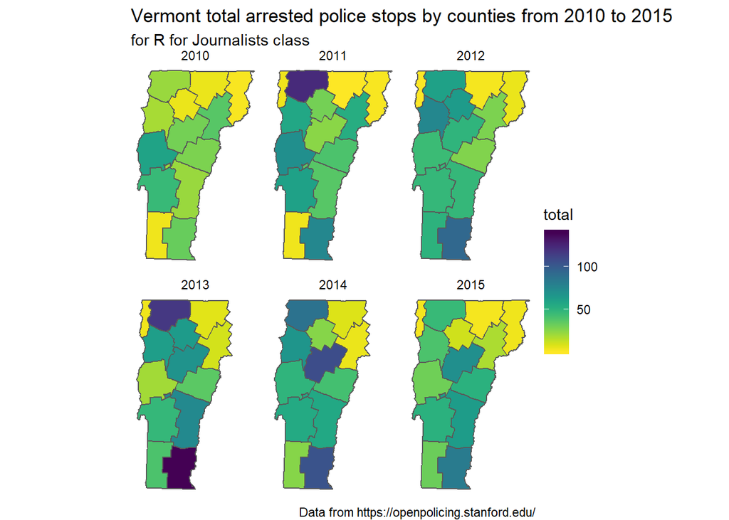

```r
ggplot(vmt_stops_arrested) +
  facet_wrap(~years) +
  geom_sf(aes(fill=total)) +
  scale_fill_viridis(direction=-1) +
  scale_color_viridis(direction=-1) +
  theme_void()+
  theme(panel.grid.major = element_line(colour = 'transparent')) +
  labs(title = "Vermont total arrested police stops by counties from 2010 to 2015",
       subtitle = "for R for Journalists class",
       caption = "Data from https://openpolicing.stanford.edu/")
```

# Police stops in 2015

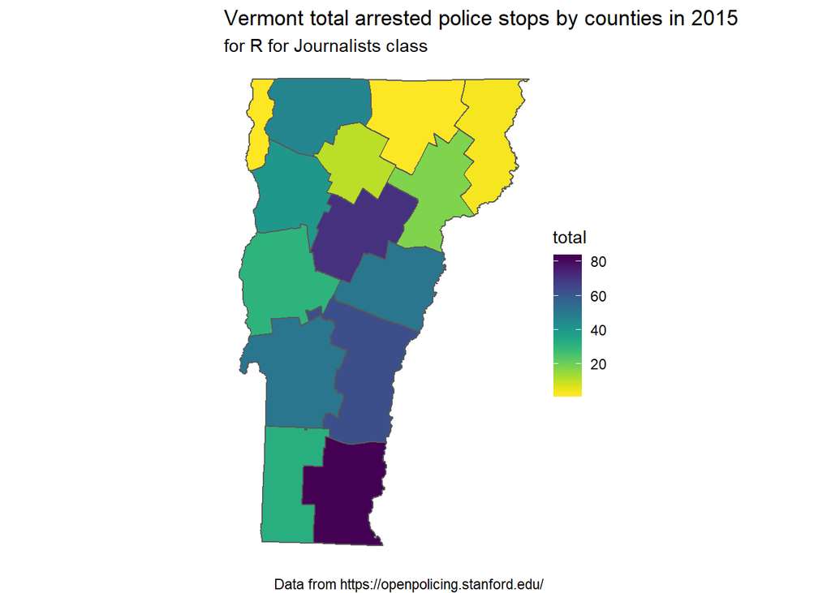

```r
## select 2015 only
vmt_stops_arrested %>%
  filter(years=="2015") %>%
  ggplot(aes(fill=total))+
  geom_sf() +
  scale_fill_viridis(direction=-1) +
  scale_color_viridis(direction=-1) +
  theme_void()+
  theme(panel.grid.major = element_line(colour = 'transparent')) +
  labs(title = "Vermont total arrested police stops by counties in 2015",
       subtitle = "for R for Journalists class",
       caption = "Data from https://openpolicing.stanford.edu/")
```

## Leaflet

```r
## leaflet - total stops by Vermont counties in 2015
vmt_stops_2015 <- vmt_stops_arrested %>%
  filter(years=="2015")
pal <- colorNumeric(c("Greens"), domain=vmt_stops_2015$total)
popup_sb <- paste0("Total: ", as.character(vmt_stops_2015$total))


leaflet() %>%
  addProviderTiles("CartoDB.Positron") %>%
  setView(-72.702921, 43.965932, zoom = 7) %>%
  addPolygons(data = vmt_stops_2015 ,
              fillColor = ~pal(vmt_stops_2015$total),
              fillOpacity = 0.7,
              weight = 0.2,
              smoothFactor = 0.2,
              popup = ~popup_sb) %>%
  addMarkers(lng=-72.779338, lat=44.529923, popup="<b>Stowe Mountain Resort</b>") %>%
  addLegend(pal = pal,
            values = vmt_stops_2015$total,
            position = "bottomright",
            title = "Total arrested stops")
```

[interactive chart not shown]

## Observation

From the chart below, this analysis should be further investigate by finding the ratio of white population in Vermont. We shouldn’t draw any conclusion yet.

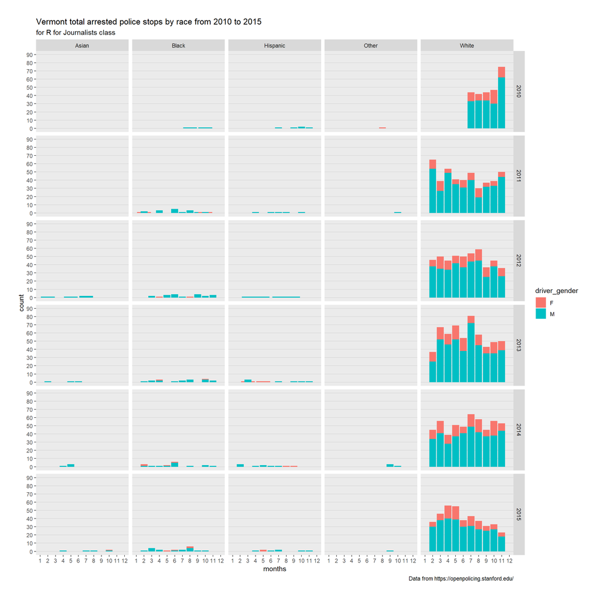

```r
## Police stops by years, race and gender
a <- stops %>%
  filter(is_arrested == "TRUE") %>%
  filter(!is.na(driver_gender)) %>%
  filter(!is.na(driver_race))

a$months <- month(a$months)

a %>%
  ggplot() +
  geom_bar(mapping=aes(x=months, fill=driver_gender)) +
  expand_limits(x = 0, y = 0) +
  facet_grid(years~driver_race) +
  scale_x_continuous(breaks=seq(1,12,1), limits=c(1,12)) +
  scale_y_continuous(breaks=seq(0,90,10), limits=c(0,90)) +
  labs(title = "Vermont total arrested police stops by race from 2010 to 2015",
       subtitle = "for R for Journalists class",
       caption = "Data from https://openpolicing.stanford.edu/") +
  theme(panel.border = element_blank(),
        panel.grid.major.x = element_blank(),
        panel.grid.minor.x = element_blank(),
        panel.grid.minor.y = element_blank(),
        panel.grid.major.y = element_line(colour = "gray85"),
        axis.line.x = element_blank(),
        plot.margin = unit(c(1,1,1,1), "cm")
        )
```

# Thank you note

It was a pleasure being part of this course. I was able to learn R throught a journalist lens and gain immediate knowledge for data exploration.